# Spine_key

```python
import pandas as pd
import numpy as np
import matplotlib.pyplot as plt
import seaborn as sns
%matplotlib inline
```

### Lower Back Pain

> About 80 percent of adults experience low back pain at some point in their lifetimes. It is the most common cause of job-related disability and a leading contributor to missed work days. In a large survey, more than a quarter of adults reported experiencing low back pain during the past 3 months [[1]](https://www.ninds.nih.gov/DISORDERS/PATIENT-CAREGIVER-EDUCATION/FACT-SHEETS/LOW-BACK-PAIN-FACT-SHEET)

It can be caused by a variety of problems with any parts of the complex, interconnected network of spinal muscles, nerves, bones, discs or tendons in the lumbar spine.

While lower back pain is extremely common, the symptoms and severity of lower back pain vary greatly. A simple lower back muscle strain might be excruciating enough to necessitate an emergency room visit, while a degenerating disc might cause only mild, intermittent discomfort.

Typical sources of low back pain include:

- The large nerve roots in the low back that go to the legs may be irritated.
- The smaller nerves that supply the low back may be irritated.
- The large paired lower back muscles (erector spinae) may be strained.
- The bones, ligaments or joints may be damaged.
- An intervertebral disc may be degenerating.

### Goal of the exercise

Identify if a person suffers from abnormal or normal lower back pain using collected physical spine details/data.

**Dataset:**

https://www.kaggle.com/sammy123/lower-back-pain-symptoms-dataset/

**Read the file:**

```python
data = pd.read_csv('lower_back_pain_with_extra_pain.csv', header=0)
```

```python
data.head(15)
```

|  | Col1 | Col2 | Col3 | Col4 | Col5 | Col6 | Col7 | Col8 | Col9 | Col10 | Col11 | Col12 | Class_att | Unnamed: 13 |
| --- | --- | --- | --- | --- | --- | --- | --- | --- | --- | --- | --- | --- | --- | --- |
| 0 | 63.027818 | 22.55258597 | 39.609117 | 40.475232 | 98.67291675 | -0.254400 | 0.744503 | 12.5661 | 14.5386 | 15.30468 | -28.658501 | 43.5123 | Abnormal | NaN |
| 1 | 39.056951 | 10.06099147 | 25.015378 | 28.995960 | 114.4054254 | 4.564259 | 0.415186 | 12.8874 | 17.5323 | 16.78486 | -25.530607 | 16.1102 | Abnormal | NaN |
| 2 | 68.832021 | 22.21848205 | 50.092194 | 46.613539 | 105.9851355 | -3.530317 | 0.474889 | 26.8343 | 17.4861 | 16.65897 | -29.031888 | 19.2221 | Abnormal | Prediction is done by using binary classificat... |
| 3 | 69.297008 | 24.65287791 | 44.311238 | 44.644130 | NAN | 11.211523 | 0.369345 | 23.5603 | 12.7074 | 11.42447 | -30.470246 | 18.8329 | Abnormal | NaN |
| 4 | 49.712859 | 9.652074879 | 28.317406 | 40.060784 | 108.1687249 | 7.918501 | 0.543360 | 35.4940 | 15.9546 | 8.87237 | -16.378376 | 24.9171 | Abnormal | NaN |
| 5 | 40.250200 | 13.92190658 | 25.124950 | 26.328293 | 130.3278713 | 2.230652 | 0.789993 | 29.3230 | 12.0036 | 10.40462 | -1.512209 | 9.6548 | Abnormal | Attribute1 = pelvic_incidence (numeric) |
| 6 | 53.432928 | 15.86433612 | 37.165934 | 37.568592 | 120.5675233 | 5.988551 | 0.198920 | 13.8514 | 10.7146 | 11.37832 | -20.510434 | 25.9477 | Abnormal | Attribute2 = pelvic_tilt (numeric) |
| 7 | 45.366754 | 10.75561143 | 29.038349 | 34.611142 | 117.2700675 | -10.675871 | 0.131973 | 28.8165 | 7.7676 | 7.60961 | -25.111459 | 26.3543 | Abnormal | Attribute3 = lumbar_lordosis_angle (numeric) |
| 8 | 43.790190 | 13.5337531 | 42.690814 | 30.256437 | 125.0028927 | 13.289018 | 0.190408 | 22.7085 | 11.4234 | 10.59188 | -20.020075 | 40.0276 | Abnormal | Attribute4 = sacral_slope (numeric) |
| 9 | 36.686353 | 5.010884121 | 41.948751 | 31.675469 | 84.24141517 | 0.664437 | 0.367700 | 26.2011 | 8.7380 | 14.91416 | -1.702097 | 21.4320 | Abnormal | Attribute5 = pelvic_radius (numeric) |
| 10 | 49.706610 | NAN | 31.334500 | 36.665635 | 108.6482654 | -7.825986 | 0.688010 | 31.3502 | 16.5097 | 15.17645 | -0.502127 | 18.3437 | Abnormal | Attribute6 = degree_spondylolisthesis (numeric) |
| 11 | 31.232387 | 17.71581923 | 15.500000 | 13.516568 | 120.0553988 | 0.499751 | 0.608343 | 21.4356 | 9.2589 | 14.76412 | -21.724559 | 36.4449 | Abnormal | Attribute7= pelvic_slope(numeric) |
| 12 | 48.915551 | 19.96455616 | 40.263794 | 28.950995 | 119.321358 | 8.028895 | 0.139478 | 32.7916 | 7.2049 | 8.61882 | -1.215542 | 27.3713 | Abnormal | Attribute8= Direct_tilt(numeric) |
| 13 | 53.572170 | 20.46082824 | 33.100000 | 33.111342 | 110.9666978 | 7.044803 | 0.081931 | 15.0580 | 12.8127 | 12.00109 | -1.734117 | 15.6205 | Abnormal | Attribute9= thoracic_slope(numeric) |
| 14 | 57.300227 | 24.1888846 | 47.000000 | 33.111342 | 116.8065868 | 5.766947 | 0.416722 | 16.5158 | 18.6222 | 8.51898 | -33.441303 | 13.2498 | Abnormal | Attribute10= cervical_tilt(numeric) |

**Change the column names:**

```python
data  = data.rename(columns={'Col1':'pelvic_incidence',
                             'Col2':'pelvic_tilt',
                             'Col3':'lumbar_lordosis_angle',
                             'Col4':'sacral_slope',
                             'Col5':'pelvic_radius',
                             'Col6':'degree_spondylolisthesis',
                             'Col7':'pelvic_slope',
                             'Col8':'Direct_tilt',
                             'Col9':'thoracic_slope',
                             'Col10':'cervical_tilt',
                             'Col11':'sacrum_angle',
                             'Col12':'scoliosis_slope',
                             'Class_att':'Abnormal_Normal'})
```

```python
data.head()
```

|  | pelvic_incidence | pelvic_tilt | lumbar_lordosis_angle | sacral_slope | pelvic_radius | degree_spondylolisthesis | pelvic_slope | Direct_tilt | thoracic_slope | cervical_tilt | sacrum_angle | scoliosis_slope | Abnormal_Normal | Unnamed: 13 |
| --- | --- | --- | --- | --- | --- | --- | --- | --- | --- | --- | --- | --- | --- | --- |
| 0 | 63.027818 | 22.55258597 | 39.609117 | 40.475232 | 98.67291675 | -0.254400 | 0.744503 | 12.5661 | 14.5386 | 15.30468 | -28.658501 | 43.5123 | Abnormal | NaN |
| 1 | 39.056951 | 10.06099147 | 25.015378 | 28.995960 | 114.4054254 | 4.564259 | 0.415186 | 12.8874 | 17.5323 | 16.78486 | -25.530607 | 16.1102 | Abnormal | NaN |
| 2 | 68.832021 | 22.21848205 | 50.092194 | 46.613539 | 105.9851355 | -3.530317 | 0.474889 | 26.8343 | 17.4861 | 16.65897 | -29.031888 | 19.2221 | Abnormal | Prediction is done by using binary classificat... |
| 3 | 69.297008 | 24.65287791 | 44.311238 | 44.644130 | NAN | 11.211523 | 0.369345 | 23.5603 | 12.7074 | 11.42447 | -30.470246 | 18.8329 | Abnormal | NaN |
| 4 | 49.712859 | 9.652074879 | 28.317406 | 40.060784 | 108.1687249 | 7.918501 | 0.543360 | 35.4940 | 15.9546 | 8.87237 | -16.378376 | 24.9171 | Abnormal | NaN |

**Drop the last column:**

```python
data.drop(columns=['Unnamed: 13'], inplace=True)
```

```python
data.head()
```

|  | pelvic_incidence | pelvic_tilt | lumbar_lordosis_angle | sacral_slope | pelvic_radius | degree_spondylolisthesis | pelvic_slope | Direct_tilt | thoracic_slope | cervical_tilt | sacrum_angle | scoliosis_slope | Abnormal_Normal |
| --- | --- | --- | --- | --- | --- | --- | --- | --- | --- | --- | --- | --- | --- |
| 0 | 63.027818 | 22.55258597 | 39.609117 | 40.475232 | 98.67291675 | -0.254400 | 0.744503 | 12.5661 | 14.5386 | 15.30468 | -28.658501 | 43.5123 | Abnormal |
| 1 | 39.056951 | 10.06099147 | 25.015378 | 28.995960 | 114.4054254 | 4.564259 | 0.415186 | 12.8874 | 17.5323 | 16.78486 | -25.530607 | 16.1102 | Abnormal |
| 2 | 68.832021 | 22.21848205 | 50.092194 | 46.613539 | 105.9851355 | -3.530317 | 0.474889 | 26.8343 | 17.4861 | 16.65897 | -29.031888 | 19.2221 | Abnormal |
| 3 | 69.297008 | 24.65287791 | 44.311238 | 44.644130 | NAN | 11.211523 | 0.369345 | 23.5603 | 12.7074 | 11.42447 | -30.470246 | 18.8329 | Abnormal |
| 4 | 49.712859 | 9.652074879 | 28.317406 | 40.060784 | 108.1687249 | 7.918501 | 0.543360 | 35.4940 | 15.9546 | 8.87237 | -16.378376 | 24.9171 | Abnormal |

**Descibe the data set:**

```python
data.describe()
```

|  | pelvic_incidence | lumbar_lordosis_angle | sacral_slope | degree_spondylolisthesis | pelvic_slope | Direct_tilt | thoracic_slope | cervical_tilt | sacrum_angle | scoliosis_slope |
| --- | --- | --- | --- | --- | --- | --- | --- | --- | --- | --- |
| count | 310.000000 | 310.000000 | 310.000000 | 310.000000 | 310.000000 | 310.000000 | 310.000000 | 310.000000 | 310.000000 | 310.000000 |
| mean | 60.496653 | 51.930930 | 42.953831 | 26.296694 | 0.472979 | 21.321526 | 13.064511 | 11.933317 | -14.053139 | 25.645981 |
| std | 17.236520 | 18.554064 | 13.423102 | 37.559027 | 0.285787 | 8.639423 | 3.399713 | 2.893265 | 12.225582 | 10.450558 |
| min | 26.147921 | 14.000000 | 13.366931 | -11.058179 | 0.003220 | 7.027000 | 7.037800 | 7.030600 | -35.287375 | 7.007900 |
| 25% | 46.430294 | 37.000000 | 33.347122 | 1.603727 | 0.224367 | 13.054400 | 10.417800 | 9.541140 | -24.289522 | 17.189075 |
| 50% | 58.691038 | 49.562398 | 42.404912 | 11.767934 | 0.475989 | 21.907150 | 12.938450 | 11.953835 | -14.622856 | 24.931950 |
| 75% | 72.877696 | 63.000000 | 52.695888 | 41.287352 | 0.704846 | 28.954075 | 15.889525 | 14.371810 | -3.497094 | 33.979600 |
| max | 129.834041 | 125.742385 | 121.429566 | 418.543082 | 0.998827 | 36.743900 | 19.324000 | 16.821080 | 6.972071 | 44.341200 |

**Find the data types of the features in the table:**

```python
data.dtypes
```

```
pelvic_incidence            float64
pelvic_tilt                  object
lumbar_lordosis_angle       float64
sacral_slope                float64
pelvic_radius                object
degree_spondylolisthesis    float64
pelvic_slope                float64
Direct_tilt                 float64
thoracic_slope              float64
cervical_tilt               float64
sacrum_angle                float64
scoliosis_slope             float64
Abnormal_Normal              object
dtype: object
```

**Label abnormal/normal as 1 and 0:**

```python
labels = {'Abnormal': 1, 'Normal': 0}

data['Labels'] = data['Abnormal_Normal'].map(labels)
```

**Find if the classes are balanced:**

```python
data['Labels'].value_counts()
```

```
1    210
0    100
Name: Labels, dtype: int64
```

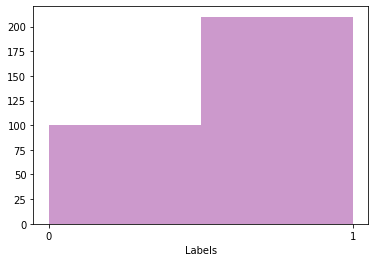

```python
sns.distplot(data['Labels'],hist=True, kde=False, bins=2, color='purple')
plt.xticks([0,1]);
```

**Find the number of missing values in the dataset:**

```python
data.isna().sum()
```

```
pelvic_incidence            0
pelvic_tilt                 0
lumbar_lordosis_angle       0
sacral_slope                0
pelvic_radius               0
degree_spondylolisthesis    0
pelvic_slope                0
Direct_tilt                 0
thoracic_slope              0
cervical_tilt               0
sacrum_angle                0
scoliosis_slope             0
Abnormal_Normal             0
Labels                      0
dtype: int64
```

Columns `pelvic_tilt` and `pelvis_radius` contain missing values that are not recognized as NaNs.

The first step is to replace those values with NaNs.

**Replace missing values with NaNs:**

```python
data.replace('NAN', np.NaN, inplace=True)
```

```python
data.isna().sum()
```

```
pelvic_incidence             0
pelvic_tilt                 14
lumbar_lordosis_angle        0
sacral_slope                 0
pelvic_radius               13
degree_spondylolisthesis     0
pelvic_slope                 0
Direct_tilt                  0
thoracic_slope               0
cervical_tilt                0
sacrum_angle                 0
scoliosis_slope              0
Abnormal_Normal              0
Labels                       0
dtype: int64
```

**Explore both the distribution of single variables and the relationships between two variables with pair plots:**

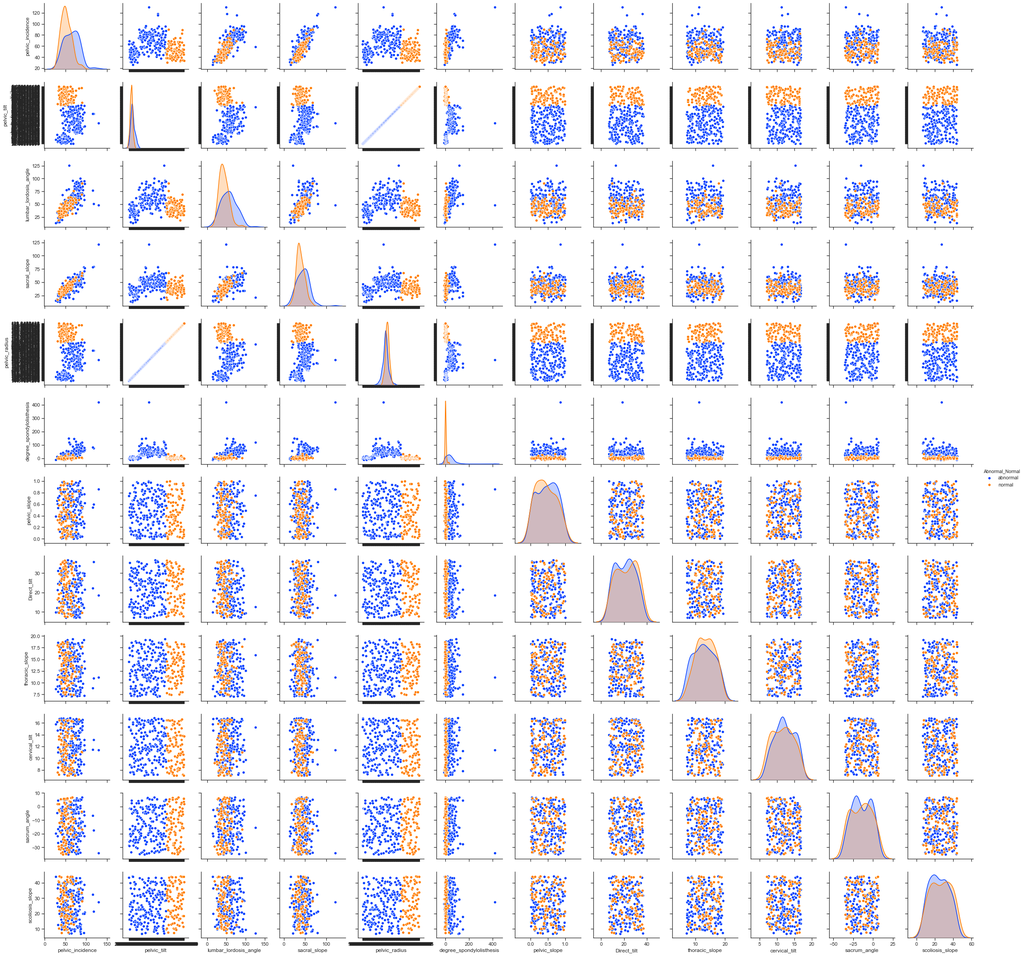

```python
tmpdf = data.dropna()
sns.set(style='ticks', color_codes=True)
s = sns.pairplot(tmpdf.iloc[:,:-1], hue='Abnormal_Normal', palette='bright', dropna=True)
new_labels = ['abnormal', 'normal']
for t, l in zip(s._legend.texts, new_labels):
    t.set_text(l)
```

**Explore the correlation between features:**

Drop the rows with NaNs so that the columns containing NaNs appear in the correlation matrix.

```python
# standard correlation coefficient, Pearson's
data_corr = data.iloc[:,:-2].dropna()
data_corr.head()
```

|  | pelvic_incidence | pelvic_tilt | lumbar_lordosis_angle | sacral_slope | pelvic_radius | degree_spondylolisthesis | pelvic_slope | Direct_tilt | thoracic_slope | cervical_tilt | sacrum_angle | scoliosis_slope |
| --- | --- | --- | --- | --- | --- | --- | --- | --- | --- | --- | --- | --- |
| 0 | 63.027818 | 22.55258597 | 39.609117 | 40.475232 | 98.67291675 | -0.254400 | 0.744503 | 12.5661 | 14.5386 | 15.30468 | -28.658501 | 43.5123 |
| 1 | 39.056951 | 10.06099147 | 25.015378 | 28.995960 | 114.4054254 | 4.564259 | 0.415186 | 12.8874 | 17.5323 | 16.78486 | -25.530607 | 16.1102 |
| 2 | 68.832021 | 22.21848205 | 50.092194 | 46.613539 | 105.9851355 | -3.530317 | 0.474889 | 26.8343 | 17.4861 | 16.65897 | -29.031888 | 19.2221 |
| 4 | 49.712859 | 9.652074879 | 28.317406 | 40.060784 | 108.1687249 | 7.918501 | 0.543360 | 35.4940 | 15.9546 | 8.87237 | -16.378376 | 24.9171 |
| 5 | 40.250200 | 13.92190658 | 25.124950 | 26.328293 | 130.3278713 | 2.230652 | 0.789993 | 29.3230 | 12.0036 | 10.40462 | -1.512209 | 9.6548 |

```python
data_corr.dtypes
```

```
pelvic_incidence            float64
pelvic_tilt                  object
lumbar_lordosis_angle       float64
sacral_slope                float64
pelvic_radius                object
degree_spondylolisthesis    float64
pelvic_slope                float64
Direct_tilt                 float64
thoracic_slope              float64
cervical_tilt               float64
sacrum_angle                float64
scoliosis_slope             float64
dtype: object
```

```python
data_corr=data_corr.astype('float64')
```

```python
data_corr.isna().sum()
```

```
pelvic_incidence            0
pelvic_tilt                 0
lumbar_lordosis_angle       0
sacral_slope                0
pelvic_radius               0
degree_spondylolisthesis    0
pelvic_slope                0
Direct_tilt                 0
thoracic_slope              0
cervical_tilt               0
sacrum_angle                0
scoliosis_slope             0
dtype: int64
```

```python
corr_matrix = data_corr.corr()
```

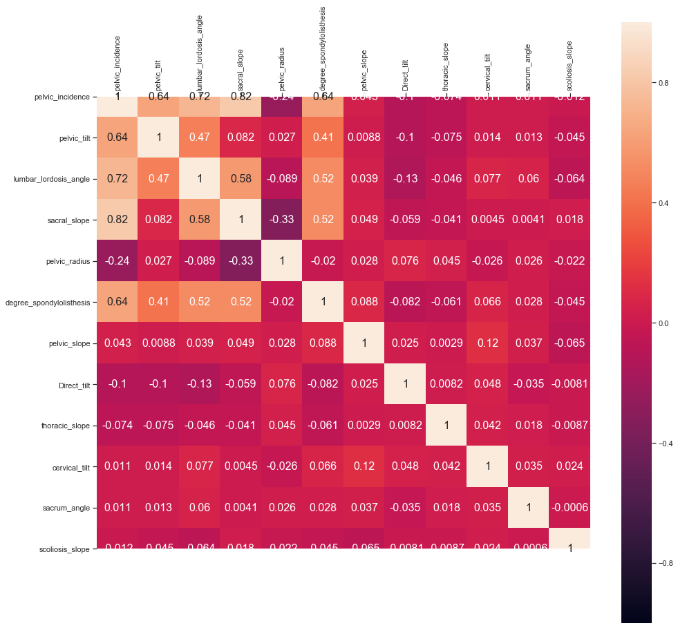

```python
fig, ax = plt.subplots(figsize=(16,16))
sns.heatmap(corr_matrix, square=True, annot=True, cbar=True,
            ax=ax, vmin=-1, vmax=1, annot_kws={"size": 16})
ax.set_xticklabels(ax.xaxis.get_majorticklabels(), rotation=90)
ax.xaxis.set_ticks_position('top');
```

```python
data.drop(columns=['sacral_slope'], inplace=True)
```

```python
tmpdf2 = tmpdf.iloc[:,:-2].astype('float64')
tmpdf2.head()
```

|  | pelvic_incidence | pelvic_tilt | lumbar_lordosis_angle | sacral_slope | pelvic_radius | degree_spondylolisthesis | pelvic_slope | Direct_tilt | thoracic_slope | cervical_tilt | sacrum_angle | scoliosis_slope |
| --- | --- | --- | --- | --- | --- | --- | --- | --- | --- | --- | --- | --- |
| 0 | 63.027818 | 22.552586 | 39.609117 | 40.475232 | 98.672917 | -0.254400 | 0.744503 | 12.5661 | 14.5386 | 15.30468 | -28.658501 | 43.5123 |
| 1 | 39.056951 | 10.060991 | 25.015378 | 28.995960 | 114.405425 | 4.564259 | 0.415186 | 12.8874 | 17.5323 | 16.78486 | -25.530607 | 16.1102 |
| 2 | 68.832021 | 22.218482 | 50.092194 | 46.613539 | 105.985135 | -3.530317 | 0.474889 | 26.8343 | 17.4861 | 16.65897 | -29.031888 | 19.2221 |
| 4 | 49.712859 | 9.652075 | 28.317406 | 40.060784 | 108.168725 | 7.918501 | 0.543360 | 35.4940 | 15.9546 | 8.87237 | -16.378376 | 24.9171 |
| 5 | 40.250200 | 13.921907 | 25.124950 | 26.328293 | 130.327871 | 2.230652 | 0.789993 | 29.3230 | 12.0036 | 10.40462 | -1.512209 | 9.6548 |

**Explore the existance of outliers:**

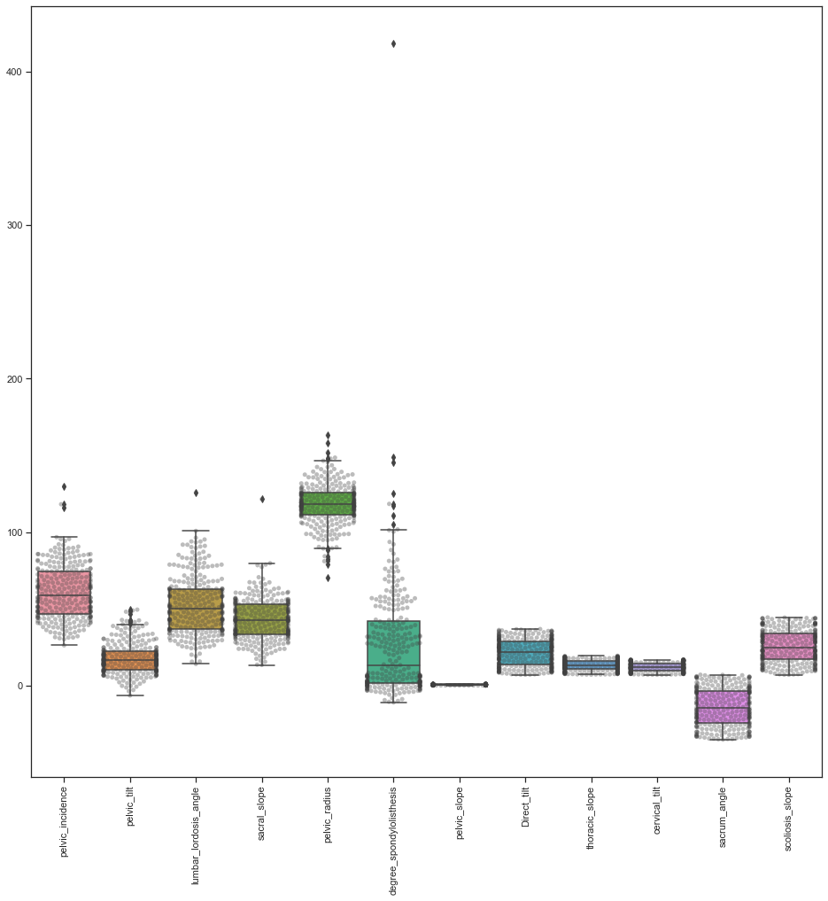

```python
fig, ax = plt.subplots(figsize=(16,16))
sns.boxplot(data=tmpdf2,ax=ax)
sns.swarmplot(data=tmpdf2,ax=ax, color='.25', alpha=0.35)
ax.set_xticklabels(ax.xaxis.get_majorticklabels(), rotation=90);
```

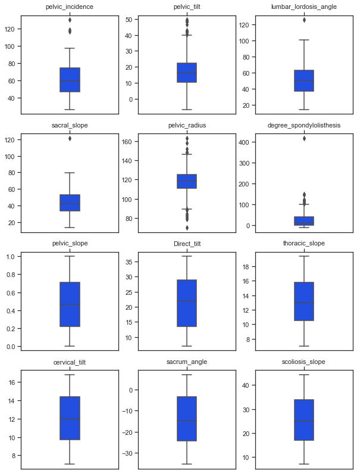

```python
fig, axes = plt.subplots(4,3, figsize=(10,14))
i = 0
for c,ax in zip(tmpdf2.columns, axes.flat):
    d = tmpdf2[c].values
    sns.boxplot(data=d, ax=ax, palette='bright', width=0.2)
    ax.set_xticklabels(labels=[list(tmpdf2.columns)[i]], rotation=0)
    ax.xaxis.set_ticks_position('top')
    i=i+1;
```

```python
outlier = max(data['degree_spondylolisthesis'].index)
data.drop([outlier], inplace=True)
```

```python
data.shape
```

```
(309, 13)
```

**Explore the distribution of values for each feature:**

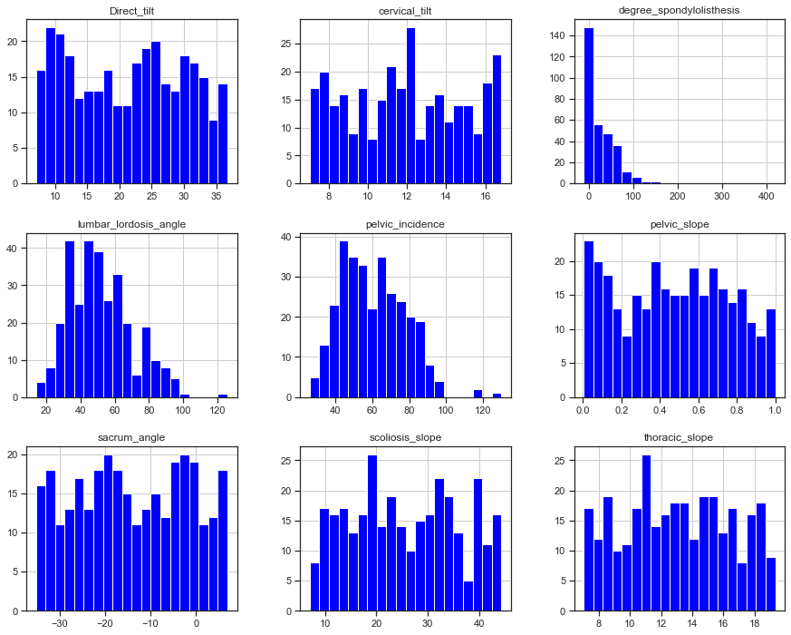

```python
hist = data.iloc[:,:11]
hist.hist(figsize=(15,12),bins = 20, color='blue');
```

**Perform a normality test to find if the data follows a normal distribution:**

Kolmogorov-Smirnov test performs a test of the distribution G(x) of an observed random variable against a given distribution F(x).

Under the null hypothesis the two distributions are identical, G(x)=F(x).

The KS test is only valid for continuous distributions.

```python
# create a function to evaluate normality
from colorama import Fore
from scipy.stats import kstest # Kstest

def ks_test(data):
    """Perform the Kolmogorov-Smirnov test for goodness of fit"""

    stat, p = kstest(data, 'norm')
    assert(not np.isnan(stat) and not np.isnan(p))
    print('Statistics=%.3f, p=%.3f' % (stat, p))

    # interpret
    alpha = 0.05
    if p > alpha:
        print(Fore.BLUE, '+ Sample DOES LOOK Gaussian (fail to reject H0)')
    else:
        print(Fore.RED, '- Sample DOES NOT look Gaussian (reject H0)')
    print(Fore.RESET)
```

```python
# normality tests

data_test = data.iloc[:,:-2].dropna()
data_test = data_test.astype('float64')

for feature in data_test.columns:
    ks_test(data_test[feature])
```

```
Statistics=1.000, p=0.000
 - Sample DOES NOT look Gaussian (reject H0)

Statistics=0.957, p=0.000
 - Sample DOES NOT look Gaussian (reject H0)

Statistics=1.000, p=0.000
 - Sample DOES NOT look Gaussian (reject H0)

Statistics=1.000, p=0.000
 - Sample DOES NOT look Gaussian (reject H0)

Statistics=0.710, p=0.000
 - Sample DOES NOT look Gaussian (reject H0)

Statistics=0.501, p=0.000
 - Sample DOES NOT look Gaussian (reject H0)

Statistics=1.000, p=0.000
 - Sample DOES NOT look Gaussian (reject H0)

Statistics=1.000, p=0.000
 - Sample DOES NOT look Gaussian (reject H0)

Statistics=1.000, p=0.000
 - Sample DOES NOT look Gaussian (reject H0)

Statistics=0.775, p=0.000
 - Sample DOES NOT look Gaussian (reject H0)

Statistics=1.000, p=0.000
 - Sample DOES NOT look Gaussian (reject H0)
```

The data in each feature does not follow a normal distribution.

Before training certain algorithms the data should be scaled.

MinMax scaler transforms features by scaling each feature to a given range.

This estimator scales and translates each feature individually such that it is in the given range on the training set, e.g. between zero and one.

We are going to scale the data, evaluate normality, and transform the non-normal distributions before training the algorithm.

[figure not shown]

**Missing values:**

```python
data.dropna(inplace=True)
```

**Scale the data:**

```python
from sklearn.preprocessing import MinMaxScaler

# the range is set between two values: one value close to 0 and another value close to 1
# this is to avoid NaNs and np.inf when tranforming the data after scaling
# the data is transformed so it then follows a normal distribution

min_max_scaler = MinMaxScaler(feature_range=(0.000001, 1))
scaled = min_max_scaler.fit_transform(data.iloc[:,:-2])

data_scaled = pd.DataFrame(scaled, columns = data.columns[:-2])
```

```python
import joblib

joblib.dump(min_max_scaler, '1_scaler.pkl')
```

```
['1_scaler.pkl']
```

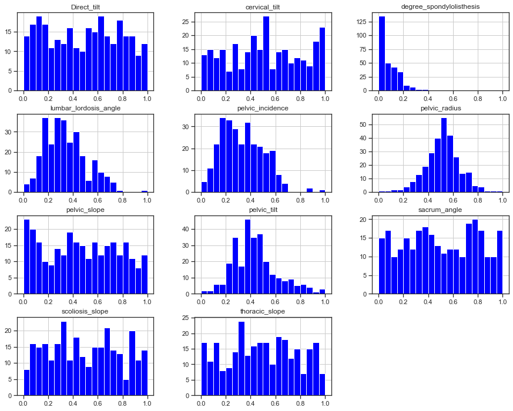

```python
data_scaled.hist(figsize=(15,12),bins = 20, color='blue');
```

**Perform a normality test after scaling the data:**

```python
for feature in data_scaled.columns:
    ks_test(data_scaled[feature])
```

```
Statistics=0.512, p=0.000
 - Sample DOES NOT look Gaussian (reject H0)

Statistics=0.530, p=0.000
 - Sample DOES NOT look Gaussian (reject H0)

Statistics=0.514, p=0.000
 - Sample DOES NOT look Gaussian (reject H0)

Statistics=0.569, p=0.000
 - Sample DOES NOT look Gaussian (reject H0)

Statistics=0.500, p=0.000
 - Sample DOES NOT look Gaussian (reject H0)

Statistics=0.500, p=0.000
 - Sample DOES NOT look Gaussian (reject H0)

Statistics=0.500, p=0.000
 - Sample DOES NOT look Gaussian (reject H0)

Statistics=0.500, p=0.000
 - Sample DOES NOT look Gaussian (reject H0)

Statistics=0.500, p=0.000
 - Sample DOES NOT look Gaussian (reject H0)

Statistics=0.500, p=0.000
 - Sample DOES NOT look Gaussian (reject H0)

Statistics=0.500, p=0.000
 - Sample DOES NOT look Gaussian (reject H0)
```

The data in each feature does not follow a normal distribution after scaling.

**Transform the data so it follows a normal distribution:**

Apply a power transform featurewise to make data more Gaussian-like.

Power transforms are a family of parametric, monotonic transformations that are applied to make data more Gaussian-like.

PowerTransformer supports the Box-Cox transform and the Yeo-Johnson transform.

Box-Cox requires input data to be strictly positive, while Yeo-Johnson supports both positive or negative data.

By default, zero-mean, unit-variance normalization is applied to the transformed data.

```python
data_scaled.head()
```

|  | pelvic_incidence | pelvic_tilt | lumbar_lordosis_angle | pelvic_radius | degree_spondylolisthesis | pelvic_slope | Direct_tilt | thoracic_slope | cervical_tilt | sacrum_angle | scoliosis_slope |
| --- | --- | --- | --- | --- | --- | --- | --- | --- | --- | --- | --- |
| 0 | 0.355689 | 0.519900 | 0.229181 | 0.307462 | 0.025149 | 0.744555 | 0.186396 | 0.610506 | 0.845115 | 0.156862 | 0.977797 |
| 1 | 0.124502 | 0.296784 | 0.098579 | 0.476649 | 0.036366 | 0.413784 | 0.197208 | 0.854170 | 0.996300 | 0.230879 | 0.243813 |
| 2 | 0.411667 | 0.513933 | 0.322995 | 0.386098 | 0.017524 | 0.473751 | 0.666534 | 0.850410 | 0.983442 | 0.148027 | 0.327167 |
| 3 | 0.227273 | 0.289480 | 0.128130 | 0.409580 | 0.044174 | 0.542524 | 0.957940 | 0.725758 | 0.188119 | 0.447451 | 0.479712 |
| 4 | 0.136010 | 0.365745 | 0.099560 | 0.647880 | 0.030934 | 0.790245 | 0.750280 | 0.404178 | 0.344623 | 0.799234 | 0.070900 |

```python
from sklearn.preprocessing import PowerTransformer

pt = PowerTransformer(method='yeo-johnson') #method='yeo-johnson': default
transformed = pt.fit_transform(data_scaled)

data_transformed = pd.DataFrame(transformed)
```

```python
joblib.dump(pt, '2_transformer.pkl')
```

```
['2_transformer.pkl']
```

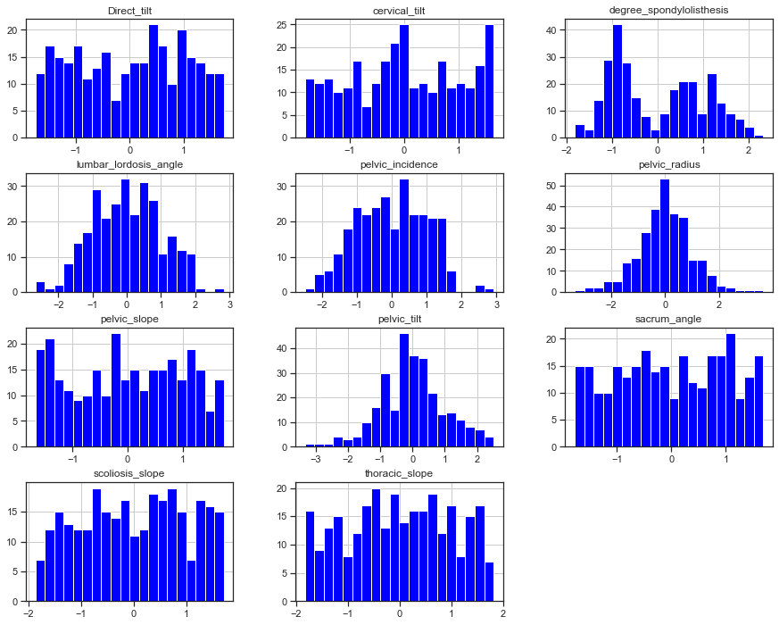

```python
data_transformed = pd.DataFrame(transformed, columns = data.columns[:-2])
data_transformed.hist(figsize=(15,12),bins = 20, color='blue');
```

**Perform normality test on the data scaled and transformed:**

```python
for feature in data_transformed.columns:
    ks_test(data_transformed[feature])
```

```
Statistics=0.049, p=0.485
 + Sample DOES LOOK Gaussian (fail to reject H0)

Statistics=0.044, p=0.649
 + Sample DOES LOOK Gaussian (fail to reject H0)

Statistics=0.042, p=0.734
 + Sample DOES LOOK Gaussian (fail to reject H0)

Statistics=0.059, p=0.277
 + Sample DOES LOOK Gaussian (fail to reject H0)

Statistics=0.158, p=0.000
 - Sample DOES NOT look Gaussian (reject H0)

Statistics=0.077, p=0.067
 + Sample DOES LOOK Gaussian (fail to reject H0)

Statistics=0.078, p=0.060
 + Sample DOES LOOK Gaussian (fail to reject H0)

Statistics=0.058, p=0.281
 + Sample DOES LOOK Gaussian (fail to reject H0)

Statistics=0.061, p=0.229
 + Sample DOES LOOK Gaussian (fail to reject H0)

Statistics=0.095, p=0.011
 - Sample DOES NOT look Gaussian (reject H0)

Statistics=0.065, p=0.171
 + Sample DOES LOOK Gaussian (fail to reject H0)
```

**Split the data set in train and test sets:**

```python
from sklearn.model_selection import train_test_split

X = data_transformed
y = data.iloc[:,-1]

X_train, X_test, y_train, y_test = train_test_split(X, y, random_state=42)
```

**Train an algorithm to perform binary classification:**

```python
from sklearn.linear_model import LogisticRegression
from sklearn.model_selection import GridSearchCV

clf = LogisticRegression(class_weight='balanced', random_state=42)
param_grid = [{'C': [0.1, 1, 10, 100, 1000],
               'solver' :['newton-cg', 'lbfgs', 'liblinear', 'sag', 'saga']}]

cv=5

grid_clf = GridSearchCV(clf, param_grid, cv=cv, iid=False)
grid_clf.fit(X_train, y_train)
```

```
GridSearchCV(cv=5, error_score='raise-deprecating',
             estimator=LogisticRegression(C=1.0, class_weight='balanced',
                                          dual=False, fit_intercept=True,
                                          intercept_scaling=1, l1_ratio=None,
                                          max_iter=100, multi_class='warn',
                                          n_jobs=None, penalty='l2',
                                          random_state=42, solver='warn',
                                          tol=0.0001, verbose=0,
                                          warm_start=False),
             iid=False, n_jobs=None,
             param_grid=[{'C': [0.1, 1, 10, 100, 1000],
                          'solver': ['newton-cg', 'lbfgs', 'liblinear', 'sag',
                                     'saga']}],
             pre_dispatch='2*n_jobs', refit=True, return_train_score=False,
             scoring=None, verbose=0)
```

```python
grid_clf.best_params_
```

```
{'C': 1, 'solver': 'newton-cg'}
```

```python
best_clf = grid_clf.best_estimator_
```

```python
best_clf.fit(X_train, y_train)
```

```
LogisticRegression(C=1, class_weight='balanced', dual=False, fit_intercept=True,
                   intercept_scaling=1, l1_ratio=None, max_iter=100,
                   multi_class='warn', n_jobs=None, penalty='l2',
                   random_state=42, solver='newton-cg', tol=0.0001, verbose=0,
                   warm_start=False)
```

```python
joblib.dump(best_clf, '3_best_clf.pkl')
```

```
['3_best_clf.pkl']
```

**Find the values predicted by the model:**

```python
y_pred = best_clf.predict(X_test)
```

**Find the metrics obtained with the model:**

```python
from sklearn import metrics

print(metrics.classification_report(y_test, y_pred))
```

```
              precision    recall  f1-score   support

           0       0.68      0.77      0.72        22
           1       0.89      0.84      0.86        49

    accuracy                           0.82        71
   macro avg       0.79      0.80      0.79        71
weighted avg       0.83      0.82      0.82        71
```

```python
from sklearn.metrics import roc_auc_score

roc_auc_score(y_test, y_pred)
```

```
0.8047309833024119
```

## THRESHOLD = 0.8

```python
res = np.zeros(len(X_test))
res[np.where(best_clf.predict_proba(X_test)[:,1] > 0.8)] = 1
print(metrics.classification_report(y_test, res))
```

```
              precision    recall  f1-score   support

           0       0.55      0.95      0.70        22
           1       0.97      0.65      0.78        49

    accuracy                           0.75        71
   macro avg       0.76      0.80      0.74        71
weighted avg       0.84      0.75      0.76        71
```